# INTRODUCCIÓN AL MANEJO DE DATOS Y PROGRAMACIÓN EN R

Gustavo A. Ballen

Museu de Zoologia da Universidade de São Paulo

gaballench@gmail.com

# INTRODUCCIÓN A R: BREVE HISTORIA Y CONTEXTO

### Acerca de programación/R

- “La mayoría de los buenos programadores programan no porque esperan pago por ello o para ser adulados por el público, sino porque es divertido programar.” -Linus Torvalds
- “Programar es como conducir un auto, cuando no se sabe lo que se hace, no anda.”
- “Usar R sin aprender su gramática es como tratar de identificar carácidos; si no se sabe lo básico, solo vemos una mezcla de cosas desorganizadas con la cual no sabemos por dónde empezar.”
- “There are only two kinds of languages: the ones people complain about and the ones nobody uses” -Bjarne Stroustrup

### Programación según Bob Ross

[figure not shown]

### La importancia de R/ciencia de datos en la vida laboral

Diferentes herramientas informáticas requeridas por empleadores (Fuente: O'Really Strata Survey)

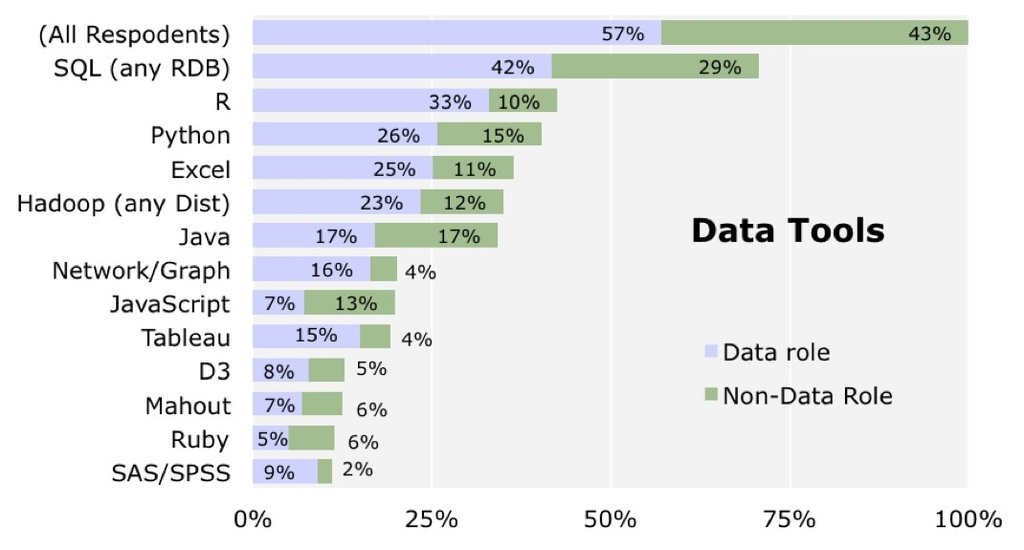

### Historia y contexto

- `S` aparece en el año 1988 desarrollado por John Chambers et al. en Bell Labs
- `R` aparece como una versión de libre acceso en el año 1993
- En el año 2001 se encuentran 110 paquetes desarrollados por la comunidad disponibles en CRAN

### Historia y contexto

[figure not shown]

### ¿Qué es R?

[figure not shown]

### ¿Qué es R?

- Un programa para análisis estadísticos
- Un dialecto de programación
- Una herramienta graficadora
- Una calculadora de escritorio
- Una herramienta de SIG
- Una herramienta de simulación
- Un generador de memes

### ¿Qué es R?

[figure not shown]

```r
MEME.GENERATOR <-
function(name.file.read.png, name.file.write.png, over.text, under.text, ps=12, height = 500, vertical.margin=20)
{
#read file
img<-readPNG(name.file.read.png)

#get size
w<-dim(img)[2]

#open new file for output
png(name.file.write.png, width=w, height=height, bg="#000000", pointsize = ps)
par(mar=c(vertical.margin,0,vertical.margin,0), xpd=NA, mgp=c(0,0,0), oma=c(0,0,0,0), ann=F)
plot.new()
plot.window(0:1, 0:1)

#fill plot with image
usr<-par("usr")
rasterImage(img, usr[1], usr[3], usr[2], usr[4])

#add text
text(.5,1.05, over.text, cex=5, col="#ffffff", pos=3)
#add text
text(.5, -.05, under.text, cex=5, col="#ffffff", pos=1)

#close image
dev.off()
}

MEME.GENERATOR("trollface.png", "meme-R.png", "algunos hacen\n estadística en R", "yo hago memes", ps=5, height=450)
```

### R en comparación con otras herramientas de análisis de datos

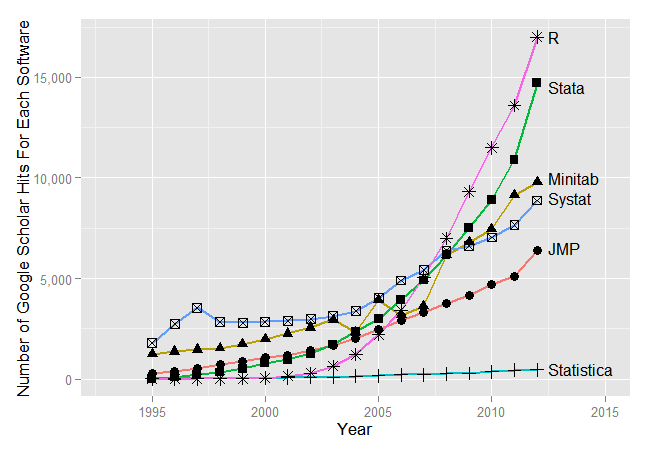

### R en comparación con otras herramientas de análisis de datos

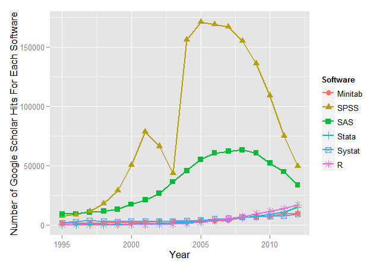

### Ventajas de R

- Libre acceso
- Corre en cualquier sistema operativo popular
- 6337 paquetes en CRAN (18 de febrero de 2015) y contando…
- Supremamente flexible
- Dialecto de programación
- Enfocado en el análisis estadístico
- Aparte de estadística, tiene un sinnúmero de aplicaciones
- Potente generador de sumarios y gráficas
- Permite la investigación reproducible

### ¿En qué sistemas operativos corre R?

- MS Windows
- Mac OSX
- Cualquier distribución popular de linux (e.g., Ubuntu, Fedora, Mandriva, Mint, Manjaro, Archlinux…)
- ¡Aún en un PlayStation3!

[figure not shown]

### ¿Qué necesito para usar R?

- Depende de la cantidad de datos a analizar y de la RAM y procesador disponibles
- Desde una computadora personal para arriba
- No hay una descripción de hardware mínima específica ofrecida por R project
- (opcional) conexión a la internet (al menos para instalar paquetes de manera fácil)

# VARIABLES, OPERADORES, FUNCIONES Y ASIGNACIÓN

### Objetos básicos

- Los objetos básicos son vectores, matrices, data frames, arrays, listas y funciones
- Objetos secundarios (o dependientes de funciones) en general son listas con metadatos
- Todo objeto es considerado una variable, pues puede contener “cualquier” valor definido por el usuario

### Vectores: Generalidades

- Son arreglos unidimensionales, análogos a los vectores matemáticos.
- Cada vector contiene una sola clase (e.g., solo elementos de clase `character`)
- Pueden concatenarse en vectores multidimensionales (e.g., un data frame es una colección de vectores)

```
[1] 5
```

```
[1] 3.141593
```

```
[1] "a" "b" "c" "d"
```

```
[1] 4+0i
```

```
[1]  TRUE FALSE FALSE  TRUE
```

```
[1] "4"          "0.1"        "TRUE"       "Characidae"
```

### Matrices: Generalidades

- Son arreglos bidimensionales
- Deben contener objetos de *la misma* clase
- Sus dimensiones son hileras * columnas

```
     [,1] [,2] [,3]
[1,]    1    4    7
[2,]    2    5    8
[3,]    3    6    9
```

### Data frames: Generalidades

- Al igual que las matrices, son arreglos bidimensionales
- Pueden contener columnas con objetos de diferentes clases
- Sus dimensiones son líneas * columnas, las columnas usualmente son las variables. Es sobre las columnas que operan las diferencias de clase

```
  var1 var2  var3   var4
1    4    a  TRUE  0.991
2    4    b FALSE  2.010
3    4    c FALSE -0.914
4    4    d  TRUE  1.395
5    4    e FALSE  0.931
```

### Arreglos multidimensionales: Generalidades

- Sus dimensiones son mayores a 2
- Su comportamiento es igual al de una matriz de tres o más dimensiones
- Su modificación requiere tener mucho cuidado con las dimensiones a modificar

### Arreglos multidimensionales: Generalidades

```r
arr <- array(data = 1:8, dim = c(2, 2, 2))
arr
```

```
, , 1

     [,1] [,2]
[1,]    1    3
[2,]    2    4

, , 2

     [,1] [,2]
[1,]    5    7
[2,]    6    8
```

[figure not shown]

### Listas: Generalidades

- Son colecciones de objetos
- Sus componentes pueden ser de cualquier clase
- Sus componentes puede tener cualquier cantidad de dimensiones

```
[[1]]
[1] 5

[[2]]
[1] "a" "b" "c" "d"

[[3]]
     [,1] [,2] [,3]
[1,]    1    4    7
[2,]    2    5    8
[3,]    3    6    9
```

```r
class(myList)
```

```
[1] "list"
```

```r
class(myList[[1]])
```

```
[1] "numeric"
```

```r
class(myList[[2]])
```

```
[1] "character"
```

```r
class(myList[[3]])
```

```
[1] "matrix"
```

### Operadores

- Modifican valores de un objeto
- Agregan valores a un objeto
- Asignan valores a un objeto
- Aritméticos
  - `+`, `-`, `*`, `/`, `^` ó `**` (exponente), `%%` (modulus), `%/%` (división entera)
- Lógicos
  - `<`, `<=`, `>`, `>=`, `==`, `!=`, `!x` (no x), `x|y`(x Ó y), `x&y` (x Y y), `isTRUE(x)` (¿es X verdadero?)
- Asignación
  - `<-` (recomendado), `=` (NO recomendado), `<<-` (usuarios pro)

### Operadores de asignación

Uso de los operadores de asignación y funciones útiles para generar datos

- `<-` asigna un valor (o valores) a una variable global (u objeto) (e.g., `variable1 <- valor`). SIEMPRE PARA VARIABLES!
- `=` asigna un valor (o valores) a una variable de nivel superior (e.g., argumento x de una función es igual a `TRUE`; más sobre esto después). NUNCA PARA VALORES!
- `<<-` es un asignador no local que funciona entre ambientes. Casi nunca se usa, solo en funciones donde se requiere alterar el valor de una variable fuera del ambiente de la función de interés. Puede pensarse en este operador como un mega-asignador que busca la variable en todos los ambientes disponibles y la modifica. USAR CON EXTREMA PRECAUCIÓN!

### Operadores de asignación: <- vs. =

- Entonces, ambos operadores sirven para realizar asignación
- Una búsqueda en google revela que algunas personas recomiendan usar `<-` , otras `=`
- La guía de estilo de Google [recomienda](http://google-styleguide.googlecode.com/svn/trunk/Rguide.xml#assignment) `<-`
- La guía de estilo de Hadley Wickham [recomienda](http://adv-r.had.co.nz/Style.html) `<-`
- John Chambers (2008) [indica](http://www.springer.com/br/book/9780387759357) que son sinónimos
- `help(`=`)` [muestra](https://stat.ethz.ch/R-manual/R-devel/library/base/html/assignOps.html) que la diferencia entre ambos es que `=` es solo permitido a nivel superior
- La info para desarrolladores de R [indica](http://developer.r-project.org/equalAssign.html) que son sinónimos sin mucho detalle
- Kun Ren [demuestra](http://renkun.me/blog/2014/01/28/difference-between-assignment-operators-in-r.html) por qué no son sinónimos
- Entonces, en qué difieren?

### Operadores de asignación: <- vs. =

```r
X <- rnorm(100)
Y <- 2*X + rnorm(100)
lm(formula = Y~X)
```

```
Call:
lm(formula = Y ~ X)

Coefficients:
(Intercept)            X
     0.1097       1.9210
```

```r
ls()
```

```
 [1] "arr"         "df"          "diffClasses" "matrix"      "myChar"
 [6] "myComplex"   "myInteger"   "myList"      "myLogical"   "myNumeric"
[11] "X"           "Y"
```

```r
X = rnorm(100)
Y = 2*X + rnorm(100)
lm(formula = Y~X)
```

```
Call:
lm(formula = Y ~ X)

Coefficients:
(Intercept)            X
    0.04823      1.97504
```

```r
ls()
```

```
 [1] "arr"         "df"          "diffClasses" "matrix"      "myChar"
 [6] "myComplex"   "myInteger"   "myList"      "myLogical"   "myNumeric"
[11] "X"           "Y"
```

### Operadores de asignación: <- vs. =

```r
X <- rnorm(100)
Y <- 2*X + rnorm(100)
lm(formula <- Y~X)
```

```
Call:
lm(formula = formula <- Y ~ X)

Coefficients:
(Intercept)            X
    0.01942      1.86774
```

```r
ls()
```

```
 [1] "arr"         "df"          "diffClasses" "formula"     "matrix"
 [6] "myChar"      "myComplex"   "myInteger"   "myList"      "myLogical"
[11] "myNumeric"   "X"           "Y"
```

### Operadores de asignación: <- vs. =

- Cómo así??? Noten el objeto llamado `formula` como resultado de llamar `ls()`. el operador `<-` ha creado este objeto en el ambiente de trabajo!
- Conclusión, los dos operadores NO son sinónimos dependiendo del contexto.
- Para crear objetos o asignar valores a los mismos, ambos operadores realizan la misma tarea
- Para asignar valores a un *argumento* dentro de la llamada de una funciíon, `=` es la elección correcta, mientras que `<-` va a crear un objeto fuera de la función, va a asignar su valor al argumento, y realizará dicha tarea
- Por qué es esta diferncia relevante? usar `<-` dentro de funciones puede generar efectos colaterales indeseados como modificación de objetos que NO queríamos modificar

### Funciones: Generalidades

- Son instrucciones automatizadas que realizan tareas específicas
- Pueden operar sobre objetos, pero no es obligatorio (e.g., `dir()`)
- Contienen opciones llamadas argumentos
- Sucedidos por paréntesis (e.g., `c()`, `nrow()`, `sd()`, `lm()`)
- Presentan tres partes principales: Formales (argumentos), cuerpo y ambiente (más sobre esto luego).
- Morfología general: `nombre(arg1, arg2, arg3, ..., argN)`

```r
rnorm(n = 3) # Nombre rnorm, argumento n
```

```
[1] -0.3125713 -0.6577676 -0.8969059
```

```r
rep(x = "GAB", times = 5) # Nombre rep, argumentos x, times
```

```
[1] "GAB" "GAB" "GAB" "GAB" "GAB"
```

```r
Sys.time() # Nombre Sys.time, sin argumentos
```

```
[1] "2015-04-29 17:15:07 BRT"
```

### Creando nuestros primeros objetos: Operadores de asignación

- Usar el operador `<-` para asignar el valor `2015` a la variable `x` y la función `c()` para asignar las vocales a la variable `vocales`

```r
x <- 2015
x
```

```
[1] 2015
```

```r
vocales <- c("a", "e", "i", "o", "u")
vocales
```

```
[1] "a" "e" "i" "o" "u"
```

### Asignando nuestros primeros valores a una variable: Secuencias

- La función `rep(x, n)` repite el valor `x` de interés un `n` numero de veces
- El operdador `:` genera secuencias de enteros entre `inicio:final` (e.g., `1:7`)
- La función `seq(from, to, by)` genera una secuencia de números entre `from` y `to`, cada `by` unidades (e.g., `from = 1`, `to = 10`, `by = 0.5`) números del 1 al 10 cada 0.5
- La función `seq_along(object)` toma la longitud del objeto, y genera una secuencia de números entre 1 y el número total de elementos en `object`. Útil en for loops.
- La función `seq_len(desired.length)` genera una secuencia entre 1 y el número `desired.length`.

### Secuencias

```r
rep(4, 5)
```

```
[1] 4 4 4 4 4
```

```r
sec <- 11:20
sec
```

```
 [1] 11 12 13 14 15 16 17 18 19 20
```

```r
seq(from = 0, to = 10, by = 2)
```

```
[1]  0  2  4  6  8 10
```

```r
length(sec)
```

```
[1] 10
```

```r
seq_along(sec) # secuencia a lo largo del número de elementos de `sec`
```

```
 [1]  1  2  3  4  5  6  7  8  9 10
```

```r
seq_len(5) # seq_len(10) == seq(from=1, to=10, by=1)
```

```
[1] 1 2 3 4 5
```

### Operaciones vectorizadas

- Se pueden modificar todos los valores de un vector a la vez tal como operan los escalares en vectores matemáticos

```r
k <- 3; V <- c(1, 2, 3, 4, 5)
k*V # xV = {kV1, kV2, kV3, kV4, kV5} = 3*1, 3*2, ..., 3*5
```

```
[1]  3  6  9 12 15
```

```r
m <- c(1, 2, 3, 4, 5)
m+V # m+V = {m1+V1, m2+V2, m3+V3, m4+V4, m5+V5} = 1+1, 2+2, ..., 5+5
```

```
[1]  2  4  6  8 10
```

- El ejemplo de arriba usó la multiplicación y la suma, pero se puede realizar cualquier operación matemática con este mismo principio.

### Operaciones vectorizadas: Reciclaje

- Qué sucede cuando tratamos de aplicar una operación vectorizada en elementos de diferente longitud?

```r
x <- 1:3
y <- 4:10
x*y # 1*4, 2*5, 3*6, [1*7, 2*8, 3*9, 1*10] entre [], 1, 2, 3, y 1 son reciclados
```

```
[1]  4 10 18  7 16 27 10
```

- Esto indica que `R` recicla los elementos del vector menor repitiéndolos hasta completar el número de elementos necesario para llevar a cabo la operación vectorizada

### Agregando valores de un vector: c()

- `c()` `c`oncatena valores a un vector
- `c(vector, valores_a_agregar)`

```r
A <- 45
A <- c(A, 23)
A
```

```
[1] 45 23
```

### Creación de matrices

- La función `matrix(data, nrow, ncol, byrow, dimnames)` crea una matriz con los datos `data`, número de hileras y columnas `nrow` y `ncol` respectivamente, llena la matriz por columa o por hilera, y tiene los nombres de sus dimensiones `dimnames`

```r
mat <- matrix(data = 1:9, nrow = 3, ncol = 3, byrow = TRUE,
              dimnames = list(c('r1', 'r2', 'r3'), c('c1', 'c2', 'c3')))
mat
```

```
   c1 c2 c3
r1  1  2  3
r2  4  5  6
r3  7  8  9
```

### Creación de data frames

- La función `data.frame(..., row.names, colnames, stringsAsFactors)` genera un arreglo por columnas, donde cada columna puede contener una clase diferente (e.g., col1 tiene elementos `integer`, col2 `numeric`, col3 `logical`, col4 `character`)
- Los puntos suspensivos contienen argumentos que identifican los grupos. Cualquier argumento conteniendo datos que no sea uno de los argumentos contenidos en la función entran a hacer parte de los datos
- `row.names` indica los nombres de cada hilera (no necesario pero útil)
- `colnames` especifica los nombres de columna
- `stringsAsFactors` determina si los elementos de clase `character` deben ser convertidos en `factor` automáticamente.

### Creación de data frames

```r
dfr <- data.frame(a = 1:5, b = rep('a', 5),
                  stringsAsFactors = FALSE)
dfr
```

```
  a b
1 1 a
2 2 a
3 3 a
4 4 a
5 5 a
```

```r
rownames(dfr) <- c('r1', 'r2', 'r3', 'r4', 'r5')
colnames(dfr) <- c('col1', 'col2')
dfr
```

```
   col1 col2
r1    1    a
r2    2    a
r3    3    a
r4    4    a
r5    5    a
```

### Creación de arreglos multidimensionales

- Creados con la función `array(data, dim, dimnames)`
- `data` determina los valores con los que vamos a llenar el arreglo
- `dim` representa el número de dimensiones (e.g., “Alto * Ancho * Profundo”)
- `dimnames` identifica los nombres de las dimensiones

### Arrays

```r
arr <- array(data = 1:8, dim = c(2, 2, 2))
arr
```

```
, , 1

     [,1] [,2]
[1,]    1    3
[2,]    2    4

, , 2

     [,1] [,2]
[1,]    5    7
[2,]    6    8
```

```r
dim(arr)
```

```
[1] 2 2 2
```

- Creamos el arreglo `arr` con dos hileras, dos columnas, y dos valores adicionales en la tercera dimensión
- Estos valores fueron creados llenando las columnas, es decir, primero llenando la primera columna de la cara anterior, luego la segunda, luego la primera columhna de la cara posterior, finalmente la segunda de la cara posterior
- El arreglo tiene entonces tres dimensiones, como podemos verlo usando la función `dim()`

### Listas

- Creadas con la función `list(...)` donde los puntos suspensivos representan objetos a ser incluidos en la lista, con o sin nombres

```r
m <- c(1, 2, 3)
n <- data.frame(a = 1:2, b = rep('a', 2))
o <- matrix(data = 1:4, nrow = 2, ncol = 2, byrow = TRUE)
lst <- list(m, n, o)
lst
```

```
[[1]]
[1] 1 2 3

[[2]]
  a b
1 1 a
2 2 a

[[3]]
     [,1] [,2]
[1,]    1    2
[2,]    3    4
```

### Listas

```
[[1]]
[1] 1 2 3

[[2]]
  a b
1 1 a
2 2 a

[[3]]
     [,1] [,2]
[1,]    1    2
[2,]    3    4
```

```r
class(lst)
```

```
[1] "list"
```

```r
class(lst[[1]])
```

```
[1] "numeric"
```

```r
class(lst[[2]])
```

```
[1] "data.frame"
```

```r
class(lst[[3]])
```

```
[1] "matrix"
```

### Modificando los valores de un arreglo: cbind

- Las funciones `D-bind()` (D- por dimensión) agregan vectores como líneas o columnas a un arreglo preexistente. Operan sobre hileras o columnas
- `cbind` agrega columnas (c por column) al primer argumento de la función.
- El número de elementos en las columnas a agregar debe ser del mismo número de hileras que el arreglo al que se pegan, o generarán reciclaje por default.
- Trabaja en arreglos bidimensionales (`matrix` o `data frame`), siempre que se respete la condición de homogeneidad de clase
- Si no se respeta homogeneidad de clase, genera coerción implícita (más sobre esto adelante)

### Modificando los valores de un arreglo: cbind

```r
dfr <- data.frame(a = c(1:5), b = rep('a', 5))
dfr
```

```
  a b
1 1 a
2 2 a
3 3 a
4 4 a
5 5 a
```

```r
cbind(dfr, c = c(T, F, F, T, T))
```

```
  a b     c
1 1 a  TRUE
2 2 a FALSE
3 3 a FALSE
4 4 a  TRUE
5 5 a  TRUE
```

### Modificando los valores de un arreglo: rbind

```r
dfr <- data.frame(a = c(1:5), b = as.character(rep('a', 5)))
dfr
```

```
  a b
1 1 a
2 2 a
3 3 a
4 4 a
5 5 a
```

```r
rbind(dfr, c(10, 'b'))
```

```
   a b
1  1 a
2  2 a
3  3 a
4  4 a
5  5 a
6 10 b
```